# Notebook

[Sebastian Raschka](http://sebastianraschka.com)

last updated: 05/21/2014

- [Open in IPython nbviewer](http://nbviewer.ipython.org/github/rasbt/One-Python-benchmark-per-day/blob/master/ipython_nbs/day7_2_jit_numpy.ipynb?create=1)
- [Link to this IPython notebook on Github](https://github.com/rasbt/One-Python-benchmark-per-day/blob/master/ipython_nbs/day7_2_jit_numpy.ipynb)
- [Link to the GitHub Repository One-Python-benchmark-per-day](https://github.com/rasbt/One-Python-benchmark-per-day)

I would be happy to hear your comments and suggestions.  
Please feel free to drop me a note via [twitter](https://twitter.com/rasbt), , or [google+](https://plus.google.com/118404394130788869227).

# Day 7.2 - One Python Benchmark per Day

## Using just-in-time compilers for speeding up NumPy array expressions

This is a follow-up to day 7, where I compared NumPy with Numexpr for various different operators. Now, I only want focus on one expression that was listed in the [Numexpr documentation](https://github.com/pydata/numexpr/blob/master/README.rst) (which supposedly show off its strengths), and compare the performance of Numexpr to the two other JIT (just-in-time) compilers Numba and parakeet.

**-> skip to the results**

### Test function in NumPy

```python
import numpy as np
```

```python
def numpy_regular(A, B):
    return(A*B-4.1*A > 2.5*B)
```

### Test function in Numexpr

[Numexpr](https://pypi.python.org/pypi/numexpr/2.4) is a "fast numerical expression evaluator for NumPy". It has a internal Virtual Machine to rewrite code more efficiently by breaking down operations into smaller chunks for the CPU cache. By using a JIT (just-in-time compiler), compilation at runtime is not necessary.

The usage is quite simple, we just have to provide the numerical expression that we want to evaluate as a string to the `evaluate` function, e.g.,

```
import numexpr
import numpy
a = numpy.array([[1, 2]])
numexpr.evaluate('a ** 2')
>> array([[1, 4]], dtype=int64)
```

```python
import numexpr as ne
```

```python
def numexpr_evaluate(A, B):
    return ne.evaluate('A*B-4.1*A > 2.5*B')
```

### Test function in Numba

Numba is using the [LLVM compiler infrastructure](http://llvm.org) for compiling Python code to machine code. Its strength is to work with NumPy arrays to speed-up the code. If you want to read more about Numba, please see refer to the original [website and documentation](http://numba.pydata.org/numba-doc/0.13/index.html).

Continuum Analytics [write on their website](http://numba.pydata.org/numba-doc/dev/arrays.html) that "the NumPy array ufunc$^1$ support in nopython node is incomplete at this time. Most if not all ufuncs should work in object mode though."

$^1$ "A universal function (or ufunc for short) is a function that operates on ndarrays in an element-by-element fashion  
(http://docs.scipy.org/doc/numpy/reference/ufuncs.html)

```python
from numba import jit
```

```python
@jit
def numba_jit(A, B):
    return A*B-4.1*A > 2.5*B
```

```python
from numba import vectorize
```

```python
@vectorize(['u1(float64, float64)'])
def numba_vectorized(A,B):
    return A*B+4.1*A > 2.5*B
```

### Test function in parakeet

Similar to Numba, [parakeet](http://www.parakeetpython.com) is a Python compiler that optimizes the runtime of numerical computations based on the NumPy data types, such as NumPy arrays.

The usage is also similar to Numba where we just have to put the `jit` decorator on top of the function we want to optimize.

```python
from parakeet import jit as para_jit
```

```python
@para_jit
def parakeet_jit(A, B):
    return A*B-4.1*A > 2.5*B
```

### Test function in Cython

Maybe we can speed things up a little bit via [Cython's C-extensions for Python](http://cython.org). Cython is basically a hybrid between C and Python and can be pictured as compiled Python code with type declarations.  
Since we are working in an IPython notebook here, we can make use of the very convenient *IPython magic*: It will take care of the conversion to C code, the compilation, and eventually the loading of the function.

Note that the static type declarations that we add via `cdef` are note required for Cython to work, but it will speed things up tremendously.

```python
%load_ext cythonmagic
```

```python
%%cython
import numpy as np
cimport numpy as np
cimport cython
@cython.boundscheck(False)
@cython.wraparound(False)
cpdef cython_unrolled(double[:, :] A, double[:, :] B):
    cdef long i, j, rows, cols
    cdef double[:, :] C
    rows = A.shape[0]
    cols = A.shape[1]
    C = np.empty((rows,cols,))
    for i in xrange(rows):
        for j in xrange(cols):
            C[i,j] = A[i,j]*B[i,j] + 4.1*A[i,j] > 2.5*B[i,j]

    return np.asarray(C)
```

# Timing

```python
import timeit

orders_n = [10**n for n in range(1, 5)]

funcs = ['numpy_regular', 'numba_jit', 'numba_vectorized',
         'parakeet_jit', 'cython_unrolled', 'numexpr_evaluate'
        ]

timings = {f:[] for f in funcs}

for n in orders_n:
    for f in funcs:
        A = np.random.rand(n,n)
        B = np.random.rand(n,n)
        timings[f].append(min(timeit.Timer('%s(A, B)' %f,
                      'from __main__ import A, B, %s' %f)
                              .repeat(repeat=3, number=10)))
```

## Setting up plots

```python
import platform
from llvm import __version__ as llvm__version__
from parakeet import __version__ as parakeet__version__
from numba import __version__ as numba__version__

def print_sysinfo():
    print '\nsystem   :', platform.system()
    print 'release  :', platform.release()
    print 'machine  :', platform.machine()
    print 'processor:', platform.processor()
    print 'interpreter:', platform.architecture()[0]

    print '\nPython version', platform.python_version()
    print 'compiler', platform.python_compiler()
    print 'NumPy version', np.__version__
    print 'Numexpr version', ne.__version__
    print 'parakeet version', parakeet__version__
    print 'Numba version', numba__version__
    print 'llvm version', llvm__version__
    print '\n\n'
```

```python
import prettytable

def summary_table(funcs):
    fit_table = prettytable.PrettyTable(['n=%s' %orders_n[-1],
                                         'function' ,
                                         'rel. performance gain'])
    fit_table.align['function'] = 'l'
    for f in funcs:
        fit_table.add_row(['', f, '{:.2f}x'.format(
            (timings['numpy_regular'][-1]/timings[f][-1]))])
    print(fit_table)
```

```python
%matplotlib inline
```

```python
import matplotlib.pyplot as plt

def plot_figures(funcs):
    fig = plt.figure(figsize=(8,8))
    for f in funcs:
        plt.plot([i**2 for i in orders_n], [i*100 for i in timings[f]],
                            alpha=0.5, label='%s' %f, marker='o', lw=2)
    plt.legend(loc='upper left')
    plt.xscale('log')
    plt.yscale('log')
    plt.grid()
    plt.xlabel('number of elements per matrix')
    plt.ylabel('time in milliseconds')
    plt.title('Approaches to evaluate the NumPy array expression "A*B-4.1*A > 2.5*B"')

    plt.show()
```

# Results

```
system   : Darwin
release  : 13.1.0
machine  : x86_64
processor: i386
interpreter: 64bit

Python version 2.7.6
compiler GCC 4.0.1 (Apple Inc. build 5493)
NumPy version 1.8.1
Numexpr version 2.4
parakeet version 0.24
Numba version 0.13.1
llvm version 0.12.4



+---------+------------------+-----------------------+
| n=10000 | function         | rel. performance gain |
+---------+------------------+-----------------------+
|         | numpy_regular    |         1.00x         |
|         | numba_jit        |         1.02x         |
|         | numba_vectorized |         4.23x         |
|         | parakeet_jit     |         11.92x        |
|         | cython_unrolled  |         4.04x         |
|         | numexpr_evaluate |         9.17x         |
+---------+------------------+-----------------------+
```

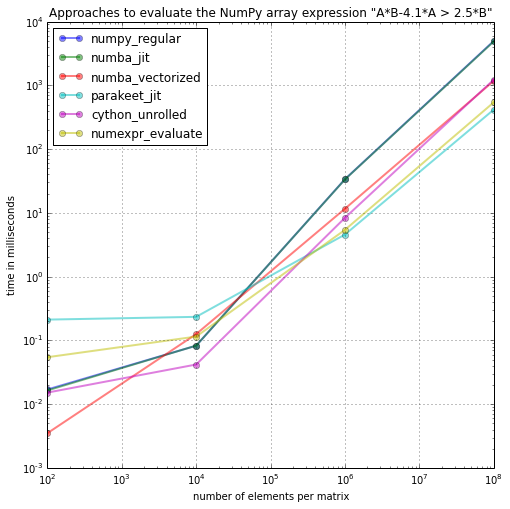

```python
print_sysinfo()
summary_table(funcs)
plot_figures(funcs)
```

```python
import multiprocessing
print('This benchmark was done on a machine with %s CPUs', multiprocessing.cpu_count())
```

[output not shown]